# Final Report Example

Author

Affiliation

Jeremy Springman

University of Pennsylvania

Published

May 23, 2025

## Research Question

**Does moving to a new city reduce the political engagement of youth?**

I hypothesize that moving to a new city will reduce an individuals’ likelihood of engaging in political or civic action. I argue that this is the case for several reasons:

- Youth have low levels of political engagement, often driven by lack of information and experience (Holbein and Hillygus 2020)
- Youth that move will have less information and experience with engagement in their new city
- Youth that move probably have fewer social ties in their new city, and ties are important for facilitating engagement (Campbell 2013)

## Research Design

I will use a linear model to estimate the relationship between levels of political engagement and whether or not an individual has moved to a new city. This design relies on the assumption that individuals that moved to a new city had similar propensities to participate to those that did not, conditional on observable covariates.

While this assumption is unrealistic, I will take several measures to rule-out potential sources of baseline differences in the propensity of moving and non-moving students to participate.

First, I will identify *specific types of participation* that are more and less likely to be affected by whether at student moves. If my hypothesis is correct, we should expect to see the more likely forms of participation to be different between moving and non-moving students, while the less likely forms of participation should not be different between moving and non-moving students.

Second, I will condition my analysis to students that move from one urban place to another urban place. While students that move from a rural area to a city are likely to be different in many important ways that could affect their propensity to participate, those that move from one city to another city will be less different.

Third, I will condition my analysis on students socio-economic status (SES). SES is one of the strongest predictors of political engagement, and students from different SES backgrounds will be different in ways that affect their propensity to participate.

Fourth, I will account for the length of time since respondents moved to their new city. My mechanisms linking moving to a new city with lower engagement (information and social ties) would predict that this effect reduces over time. Therefore, the gap between moving and non-moving students should be smaller for respondents that have been in their new city for longer.

## Research Context

I will student this research question among students at Addis Ababa University (AAU). AAU is Ethiopia’s top university, and students from around the country (and the continent) move to Addis Ababa in order to study there. Given the frequency with which youth move to a new city in order to obtain education, and the importance of universities and sites of political socialization, this is an important context in which to study the effects of moving on participation.

## Data and Variables

I am using a representative survey of students from Addis Ababa University in Ethiopia collected by DevLab researchers. This data contains two waves collected in May-June and October-November of 2022. A total of 825 students completed both waves of the survey.

The variables being used fall into two categories. First, we use variables based on survey questions measuring respondent demographics, including whether or not the student is originally from Addis Ababa, whether they came from an urban or rural setting, the number of years they have been at university, and whether or not they work to support themselves and receive financial support from their parents. Second, we use variables based on survey questions measuring political participation.

## Describing the Sample

### Demographics

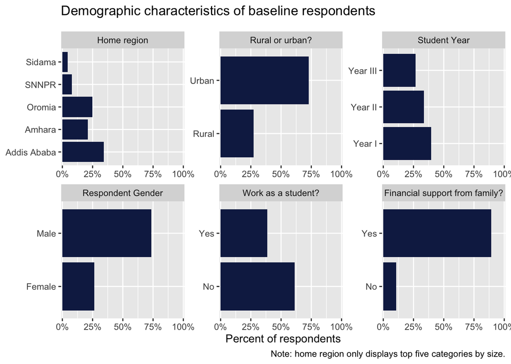

### Levels of Engagement

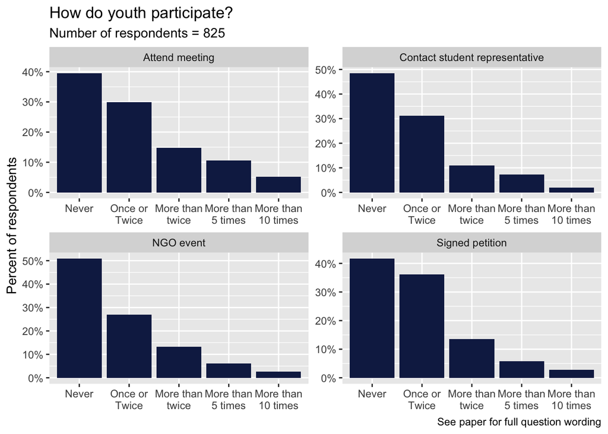

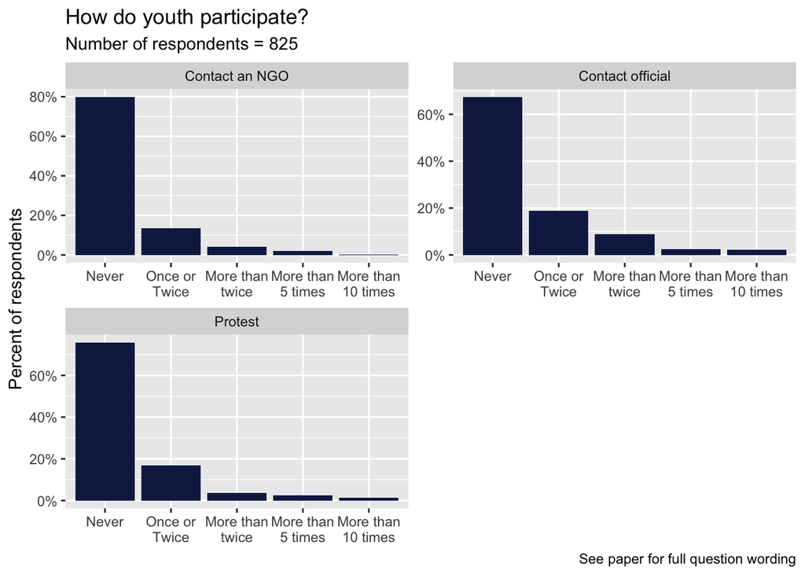

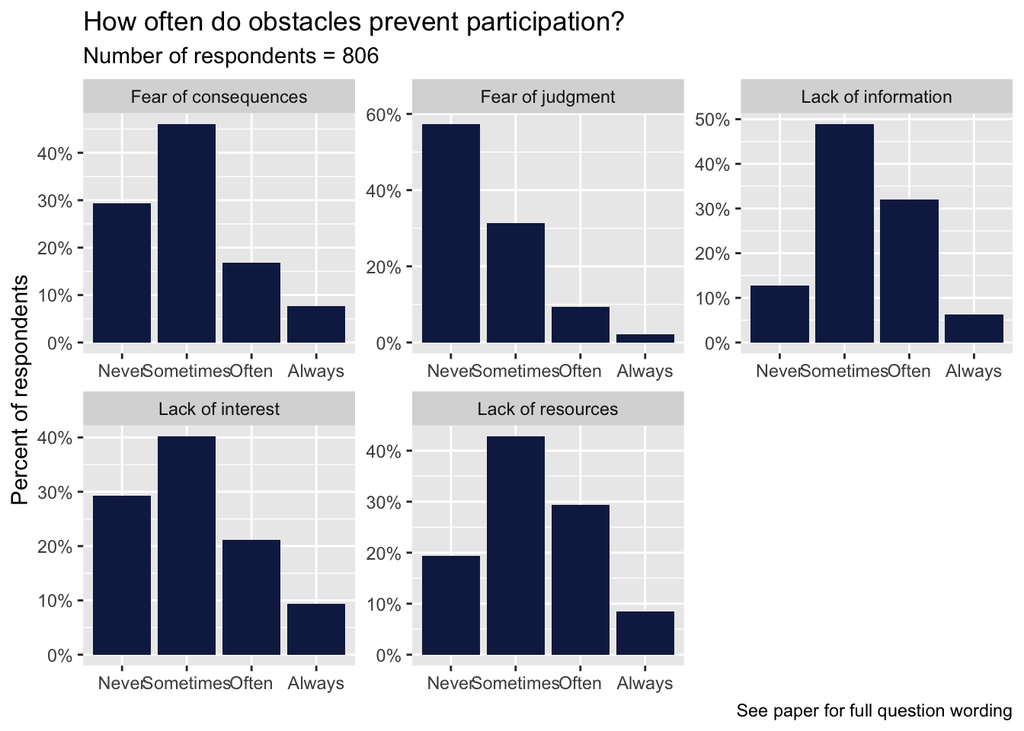

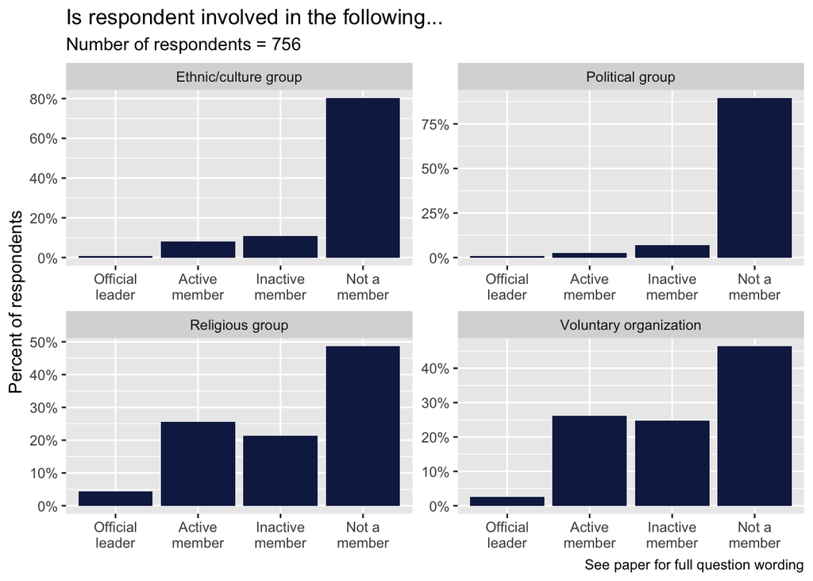

## Results

|  | Contact Official | Attend Meeting | NGO Volunteer | Sign Petition |
| --- | --- | --- | --- | --- |
| (Intercept) | 1.044*** (0.114) | 0.752*** (0.116) | 1.304*** (0.181) | 0.354*** (0.090) |
| moved | 0.178 (0.141) | 0.580*** (0.143) | 0.117 (0.222) | 0.529*** (0.110) |
| Num.Obs. | 802 | 801 | 803 | 801 |
| R2 Adj. | 0.001 | 0.019 | 0.001 | 0.027 |

## References

Campbell, David E. 2013. “Social Networks and Political Participation.” *Annual Review of Political Science* 16: 33–48.

Holbein, John B., and D. Sunshine Hillygus. 2020. *Making Young Voters: Converting Civic Attitudes into Civic Action*. Cambridge University Press.